# Indicator, Predictor & ASP Profiles

- Show All Code
- Hide All Code
- View Source

# Overview

This three-page workflow presents analyses from **Dissertation Study 1**, which used Add Health Wave I data (*N* = 6,469) to examine heterogeneity in adolescents’ positive and negative risk-taking and the developmental factors associated with different patterns of risk behavior.

This first page establishes the descriptive profile solution. It shows the indicators that defined each class and summarizes demographic and developmental predictor patterns across classes.

The next page tests whether demographic, peer, and parenting predictors distinguish class membership using posterior-probability-weighted multinomial logistic regression with BCH adjustment for classification uncertainty. The final page tests whether the ASP association differs by adolescent sex or age and presents BH-corrected pairwise comparisons across the profile analyses.

**Analysis Workflow**

**1. Profiles** → **2. Odds Ratios** → **3. Interaction & Comparisons**

Profiles · Odds Ratios · Interaction & Comparisons

Continue to Odds Ratios for inferential comparisons of class membership, or to Interaction & Comparisons for moderation and BH-corrected robustness checks.

# Indicator Profiles

### Overview

These panels show the 4-class latent profile solution’s indicator profiles from the negative and positive risk-taking indicators. Fit indices favored the four-profile solution: AIC/BIC improvements became marginal beyond four classes, the five-profile solution failed to replicate (a local maximum), and the four-profile solution showed adequate entropy (> .80) with theoretically coherent classes (LPA conducted in LatentGOLD; (Vermunt and Magidson 2005)).

A four-class latent profile analysis identified groups that differed in their joint levels of **positive risk-taking (PR)** and **negative risk-taking (NR)**:

- **C1: High PR–Low NR** (35.6%)
- **C2: Low PR–Low NR** (33.7%)
- **C3: Low PR–High NR** (15.8%)
- **C4: High PR–High NR** (14.9%)

Alcohol problems functioned as a near-binary separator: both **C1 and C2 reported essentially no alcohol problems**, while **C3 and C4 reported substantially elevated problem counts**. Within each of those two broad groupings, positive risk indicators (sports, school activities, friend disclosure, romantic involvement) were the primary source of further differentiation. However, adolescents with comparably low negative risk occupied meaningfully distinct profiles with respect to positive risk engagement (Duell and Steinberg 2019, 2021; Fryt and Szczygiel 2021).

**Data Import**

Indicator profile probabilities/means and paired-comparison significance tests across the latent class solution are read in from a local Excel results workbook from saved LatentGOLD results. Import code is not rendered.

indicator probabilities/means by class

| Risk | Indicators | Cluster1 | Cluster2 | Cluster3 | Cluster4 | Overall |
| --- | --- | --- | --- | --- | --- | --- |
| Negative | Cigarette | 0.24 | 0.35 | 0.81 | 0.74 | 0.44 |
| Negative | Skipped school | 0.14 | 0.25 | 0.49 | 0.40 | 0.27 |
| Negative | Lied about whereabouts | 0.40 | 0.45 | 0.72 | 0.75 | 0.52 |
| Negative | Night out(unsanctioned) | 0.05 | 0.09 | 0.30 | 0.23 | 0.13 |
| Negative | Dangerous dare | 0.33 | 0.38 | 0.56 | 0.51 | 0.41 |
| Negative | No seatbelt | 0.19 | 0.30 | 0.45 | 0.26 | 0.28 |
| Negative | Drove Drunk | 0.00 | 0.01 | 0.22 | 0.18 | 0.07 |
| Negative | Risky Sex | 0.05 | 0.11 | 0.28 | 0.20 | 0.13 |
| Negative | Theft | 0.12 | 0.16 | 0.35 | 0.30 | 0.20 |
| Negative | Fight | 0.22 | 0.36 | 0.50 | 0.33 | 0.33 |
| Negative | Alcohol Problems (M) | 0.00 | 0.00 | 2.86 | 2.75 | 0.86 |
| Positive | Sport Teams (M) | 1.12 | 0.90 | 0.76 | 1.15 | 1.00 |
| Positive | School Activities (M) | 1.78 | 0.00 | 0.00 | 1.86 | 0.91 |
| Positive | Problem Approach (M) | 2.91 | 2.80 | 2.84 | 2.95 | 2.87 |
| Positive | Friend Disclosure | 0.78 | 0.57 | 0.73 | 0.87 | 0.72 |
| Positive | Initiated Relationship | 0.57 | 0.58 | 0.87 | 0.89 | 0.67 |

### Wrangle Profile Data

Binary indicators (probabilities, 0–1) and continuous indicators (means, 0–3) are plotted together on a shared primary axis. Continuous values are divided by `scale_factor` before plotting so they fit the 0–1 primary axis; the right-hand secondary axis reverses that transformation to show the true 0–3 scale.

```r
# Legend labels with cluster size in parentheses
cluster_sizes <- c("C1" = 35.6, "C2" = 33.7, "C3" = 15.8, "C4" = 14.9)

cluster_labels <- c(
  "C1"      = paste0("C1 (", cluster_sizes["C1"], "%)"),
  "C2"      = paste0("C2 (", cluster_sizes["C2"], "%)"),
  "C3"      = paste0("C3 (", cluster_sizes["C3"], "%)"),
  "C4"      = paste0("C4 (", cluster_sizes["C4"], "%)"))

# Fill colors — no outlines
indicator_colors <- cluster_colors

# Scale factor: right axis max / left axis max (continuous max ~3, binary max 1)
# Continuous values are divided by this before plotting, then right axis
# Multiplies back to show true scale. Edit here if any continuous value > 3
scale_factor <- 3

# Label indicators
indicator_label_map <- c(
  WSDalc               = "Alcohol Problems",
  cigwhole             = "Cigarette",
  skipschool           = "Skipped school",
  liewhere             = "Lied about whereabouts",
  awayhome             = "Night out(unsanctioned)",
  dare_dum             = "Dangerous dare",
  seatbelt             = "No seatbelt",
  drvdrunk             = "Drove Drunk",
  BC_dum               = "Risky Sex",
  steal12M             = "Theft",
  phyfight             = "Fight",
  WSDsport             = "Sport Teams",
  WSDactivity          = "School Activities",
  avoidproblems        = "Problem Approach",
  disclose             = "Friend Disclosure",
  intitaterelationship = "Initiated Relationship")

# Continuous indicators — values can exceed 1 and read off the right axis
continuous_indicators <- c(
  "Problems from alcohol",
  "Sport Teams",
  "Extracurriculars",
  "Don't avoid problems")

# Negative panel: binary on left (0-1), continuous on right (0-3)
# → Continuous values divided by scale_factor to fit primary axis
# Positive panel: continuous on left (0-3), binary on right (0-1)
# → Binary values multiplied by scale_factor to fit primary axis
# This arrangement puts the 0-3 axes adjacent in the middle of the combined figure

neg_continuous <- c("Alcohol Problems")
pos_continuous <- c("Sport Teams", "School Activities", "Problem Approach")

profile_long <- profile_raw %>%
  pivot_longer(
    cols      = c(Cluster1, Cluster2, Cluster3, Cluster4),
    names_to  = "cluster_raw",
    values_to = "value"
  ) %>%
  mutate(
    cluster    = recode(cluster_raw,
                   "Cluster1" = "C1", "Cluster2" = "C2",
                   "Cluster3" = "C3", "Cluster4" = "C4"),
    cluster    = factor(cluster, levels = c("C1", "C2", "C3", "C4")),
    Indicators = factor(Indicators, levels = unique(Indicators)),
    # Rescale for plotting:
    # Negative: continuous / scale_factor (plots on 0-1 axis, reads off right 0-3)
    # Positive: binary * scale_factor     (plots on 0-3 axis, reads off right 0-1)
    value_plot = case_when(
      Risk == "Negative" & Indicators %in% neg_continuous ~ value / scale_factor,
      Risk == "Positive" & !Indicators %in% pos_continuous ~ value * scale_factor,
      TRUE ~ value ) )
```

### BH Correction on Pairwise Comparisons

Non-estimable rows (p = “.”) and the Intercept block (included in LatentGOLD data export) are dropped before correction is applied across all remaining tests simultaneously.

```r
# Apply Benjamini-Hochberg correction to the pairwise profile comparisons before flagging significant differences
pairs <- pairs_raw %>%
  filter(Indicator != "Intercept", `p-value` != ".") %>%
  mutate(
    p_value   = as.numeric(`p-value`),
    cluster_a = as.integer(clustera),
    cluster_b = as.integer(clusterb),
    Indicator = recode(Indicator, !!!indicator_label_map),
    pair      = paste0("C", cluster_a, " vs. C", cluster_b),
    p_adj     = p.adjust(p_value, method = "BH"),
    sig       = p_adj < .05)
```

Benjamini-Hochberg correction is applied here because every indicator is compared across all six class-pairs simultaneously; without correction, running this many pairwise tests inflates the false-positive rate well past .05 ((Benjamini and Hochberg 1995), (Benjamini and Hochberg 2000)). Overall, the negative risk indicators contributed about equally to differentiating classes, while positive risk indicators were the primary driver of separation within each alcohol-problem grouping.

```r
# Display the corrected pairwise-comparison results used to annotate the profile figures
gt(head(pairs)) |> tab_header(title = "After: BH-corrected pairwise comparisons")
```

After: BH-corrected pairwise comparisons

| Indicator | clustera | clusterb | Wald | df | p-value | p_value | cluster_a | cluster_b | pair | p_adj | sig |
| --- | --- | --- | --- | --- | --- | --- | --- | --- | --- | --- | --- |
| Alcohol Problems | 1 | 3 | 1943.2611 | 1 | 1.9e-424 | 0.0e+00 | 1 | 3 | C1 vs. C3 | 0.000000e+00 | TRUE |
| Alcohol Problems | 1 | 4 | 1698.1640 | 1 | 3.4e-371 | 0.0e+00 | 1 | 4 | C1 vs. C4 | 0.000000e+00 | TRUE |
| Alcohol Problems | 2 | 3 | 1943.2611 | 1 | 1.9e-424 | 0.0e+00 | 2 | 3 | C2 vs. C3 | 0.000000e+00 | TRUE |
| Alcohol Problems | 2 | 4 | 1698.1640 | 1 | 3.4e-371 | 0.0e+00 | 2 | 4 | C2 vs. C4 | 0.000000e+00 | TRUE |
| Alcohol Problems | 3 | 4 | 1.0661 | 1 | 0.3 | 3.0e-01 | 3 | 4 | C3 vs. C4 | 3.168539e-01 | FALSE |
| Cigarette | 1 | 2 | 29.4013 | 1 | 5.8999999999999999E-8 | 5.9e-08 | 1 | 2 | C1 vs. C2 | 9.903571e-08 | TRUE |

### Profile Figure

```r
# Builds axis labels as plotmath expressions so only the "M" renders in
# Italics (the label text and parentheses stay plain). Named by the label
# Text itself so ggplot matches each break by name — not position — which
# Matters since p_neg/p_pos (and the line/z-score panels) each only show a
# Subset of the full indicator list
label_with_M <- function(labels_vec) {
  exprs <- lapply(labels_vec, function(lbl) {
    if (lbl %in% indicator_continuous_fig) {
      bquote(.(lbl) * " (" * italic(M) * ")")
    } else {
      bquote(.(lbl))
    }
  })
  out <- as.expression(exprs)
  names(out) <- labels_vec
  out
}

axis_labels_fig <- label_with_M(levels(factor(profile_long$Indicators)))

# Make_panel() takes explicit axis configuration so negative and positive can differ

make_panel <- function(risk_label,
                       left_name = "", left_lim, left_breaks,
                       sec_transform, right_name = "", right_breaks,
                       caption_text) {

  df <- profile_long %>% filter(Risk == risk_label)

  # Create panel
  ggplot(df, aes(x = Indicators, y = value_plot, fill = cluster)) +
    geom_vline(
      xintercept = seq(1.5, length(unique(df$Indicators)) - 0.5, by = 1),
      color = "#DDDDDD",
      linewidth = 0.4) +
    geom_col(
      position = position_dodge(width = dodge_width),
      width = bar_width) +
    scale_fill_manual(
      values = indicator_colors,
      labels = cluster_labels,
      name = NULL) +
    scale_x_discrete(labels = axis_labels_fig) +
    scale_y_continuous(
      limits = left_lim,
      breaks = left_breaks,
      labels = number_format(accuracy = 0.1),
      expand = expansion(mult = c(0, 0.03)),
      sec.axis = sec_axis(
        transform = sec_transform,
        name = right_name,
        breaks = right_breaks,
        labels = number_format(accuracy = 0.1))) +
    labs(
      title = paste(risk_label, "Risk Indicators"),
      y = NULL,
      caption = str_wrap(caption_text, width = 150)) +
    base_theme +
    theme(
      # Adjust panel format from base theme
      axis.text.x = element_text(
        angle = 35,
        hjust = 1,
        size = axis_text_size),

      axis.title.y.right = element_text(
        size = axis_title_size,
        color = "gray40"),

      legend.position = "none",

      plot.caption = element_text(
        hjust = 0,
        lineheight = 1.2,
        size = 16),

      plot.title = element_text(
        size = title_size,
        face = "bold",
        hjust = 0.5))
}

# Negative: left = binary 0-1, right = continuous 0-3
p_neg <- make_panel(
  risk_label = "Negative",
  left_lim = c(0, 1.08),
  left_breaks = seq(0, 1, by = 0.2),
  sec_transform = ~ . * scale_factor,
  right_breaks = seq(0, scale_factor, by = 1),
  caption_text = paste(
    "Note. Left y-axis (0–1) = binary indicators (probability of behavior).",
    "Right y-axis (0–3) = continuous indicators (within-class mean).",
    "Continuous bars are rescaled to the primary axis for display."))

# Positive: left = continuous 0-3, right = binary 0-1
p_pos <- make_panel(
  risk_label = "Positive",
  left_lim = c(0, scale_factor * 1.08),
  left_breaks = seq(0, scale_factor, by = 1),
  sec_transform = ~ . / scale_factor,
  right_breaks = seq(0, 1, by = 0.2),
  caption_text = paste(
    "Note. Left y-axis (0–3) = continuous indicators (within-class mean).",
    "Right y-axis (0–1) = binary indicators (probability of behavior).",
    "Binary bars are rescaled to the primary axis for display."))
```

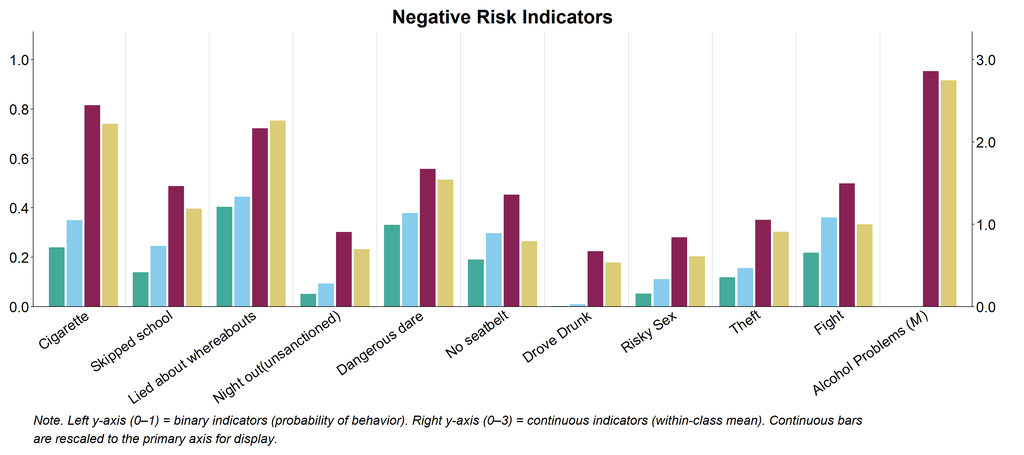

Figure 1

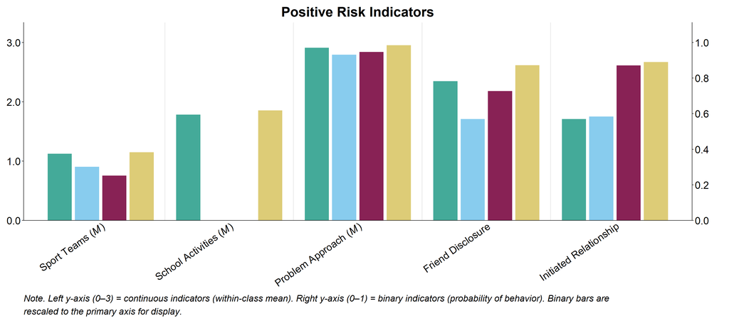

Figure 2

```r
# Display indicators with no BH-corrected pairwise class differences
nonsig <- pairs %>%
  filter(sig == FALSE) %>%
  select(Indicator, pair, p_value, p_adj) %>%
  mutate(across(c(p_value, p_adj), ~ round(.x, 3))) %>%
  arrange(Indicator, pair)

kable(nonsig,
      col.names = c("Indicator", "Comparison", "Raw p", "BH-adjusted p"),
      caption   = "Non-significant pairwise comparisons after Benjamini-Hochberg correction (FDR < .05).")
```

Table 1: Non-significant pairwise comparisons after Benjamini-Hochberg correction (FDR < .05).

| Indicator | Comparison | Raw p | BH-adjusted p |
| --- | --- | --- | --- |
| Alcohol Problems | C3 vs. C4 | 0.300 | 0.317 |
| Dangerous dare | C3 vs. C4 | 0.170 | 0.186 |
| Drove Drunk | C3 vs. C4 | 0.085 | 0.099 |
| Fight | C2 vs. C4 | 0.260 | 0.281 |
| Initiated Relationship | C1 vs. C2 | 0.500 | 0.505 |
| Initiated Relationship | C3 vs. C4 | 0.330 | 0.345 |
| Lied about whereabouts | C1 vs. C2 | 0.051 | 0.061 |
| Lied about whereabouts | C3 vs. C4 | 0.290 | 0.310 |
| No seatbelt | C2 vs. C4 | 0.160 | 0.181 |
| Problem Approach | C1 vs. C3 | 0.170 | 0.186 |
| Problem Approach | C1 vs. C4 | 0.380 | 0.388 |
| Problem Approach | C2 vs. C3 | 0.350 | 0.362 |
| Problem Approach | C3 vs. C4 | 0.073 | 0.086 |
| School Activities | C1 vs. C4 | 0.170 | 0.186 |
| Sport Teams | C1 vs. C4 | 0.630 | 0.630 |
| Theft | C3 vs. C4 | 0.150 | 0.172 |

### Significant Comparisons by Profile

```r
# Display significant BH-corrected comparisons organized by class pair
sig_pairs <- pairs %>% filter(sig == TRUE)

by_cluster <- bind_rows(
  sig_pairs %>% select(cluster = cluster_a, Indicator),
  sig_pairs %>% select(cluster = cluster_b, Indicator)
) %>%
  mutate(cluster = paste0("C", cluster)) %>%
  count(cluster, name = "n_significant") %>%
  arrange(cluster)

kable(by_cluster,
      col.names = c("Profile", "Number of Significant Pairwise Comparisons"),
      caption   = "Count of significant pairwise comparisons (BH-corrected, FDR < .05) involving each profile.")
```

Table 2: Count of significant pairwise comparisons (BH-corrected, FDR < .05) involving each profile.

| Profile | Number of Significant Pairwise Comparisons |
| --- | --- |
| C1 | 41 |
| C2 | 41 |
| C3 | 38 |
| C4 | 36 |

### Significant Comparisons by Indicator

```r
# Display significant BH-corrected comparisons organized by indicator
by_indicator <- pairs %>%
  group_by(Indicator) %>%
  summarise(
    n_total       = n(),
    n_significant = sum(sig),
    n_nonsig      = sum(!sig)
  ) %>%
  arrange(desc(n_significant))

kable(by_indicator,
      col.names = c("Indicator", "Total Comparisons", "Significant", "Non-Significant"),
      caption   = "Count of significant and non-significant pairwise comparisons (BH-corrected, FDR < .05) by indicator.")
```

Table 3: Count of significant and non-significant pairwise comparisons (BH-corrected, FDR < .05) by indicator.

| Indicator | Total Comparisons | Significant | Non-Significant |
| --- | --- | --- | --- |
| Cigarette | 6 | 6 | 0 |
| Friend Disclosure | 6 | 6 | 0 |
| Night out(unsanctioned) | 6 | 6 | 0 |
| Risky Sex | 6 | 6 | 0 |
| Skipped school | 6 | 6 | 0 |
| Dangerous dare | 6 | 5 | 1 |
| Drove Drunk | 6 | 5 | 1 |
| Fight | 6 | 5 | 1 |
| No seatbelt | 6 | 5 | 1 |
| Sport Teams | 6 | 5 | 1 |
| Theft | 6 | 5 | 1 |
| Alcohol Problems | 5 | 4 | 1 |
| Initiated Relationship | 6 | 4 | 2 |
| Lied about whereabouts | 6 | 4 | 2 |
| School Activities | 5 | 4 | 1 |
| Problem Approach | 6 | 2 | 4 |

# Indicator Profiles - Standardized

### Standardized Profile Panels

Raw indicator profiles above mix binary probabilities and continuous means on different scales; z-scoring every indicator here puts all of them on the same standardized axis so their relative separation across classes can be compared directly, which the raw panels cannot show on their own.

### Variable Labels

```r
# Variable labels for plots
indicator_label_map <- c(
  WSDalc               = "Alcohol Problems",
  cigwhole             = "Cigarette",
  skipschool           = "Skipped school",
  liewhere             = "Lied about whereabouts",
  awayhome             = "Night out(unsanctioned)",
  dare_dum             = "Dangerous dare",
  seatbelt             = "No seatbelt",
  drvdrunk             = "Drove Drunk",
  BC_dum               = "Risky Sex",
  steal12M             = "Theft",
  phyfight             = "Fight",
  WSDsport             = "Sport Teams",
  WSDactivity          = "School Activities",
  avoidproblems        = "Problem Approach",
  disclose             = "Friend Disclosure",
  intitaterelationship = "Initiated Relationship")

# "Negative" = negative risk indicators; "Positive" = positive risk indicators
indicator_risk_panel <- c(
  WSDalc               = "Negative",
  cigwhole             = "Negative",
  skipschool           = "Negative",
  liewhere             = "Negative",
  awayhome             = "Negative",
  dare_dum             = "Negative",
  seatbelt             = "Negative",
  drvdrunk             = "Negative",
  BC_dum               = "Negative",
  steal12M             = "Negative",
  phyfight             = "Negative",
  WSDsport             = "Positive",
  WSDactivity          = "Positive",
  avoidproblems        = "Positive",
  disclose             = "Positive",
  intitaterelationship = "Positive")

# Desired x-axis order within each panel — edit to reorder bars
neg_order <- c(
  "WSDalc", "cigwhole", "skipschool", "liewhere", "awayhome",
  "dare_dum", "seatbelt", "drvdrunk", "BC_dum", "steal12M", "phyfight")

pos_order <- c(
  "WSDsport", "WSDactivity", "avoidproblems", "disclose", "intitaterelationship")
```

### Standardization

Class probabilities and indicator values are read in from the dissertation’s saved SPSS output (a 4-class LCA solution with an auxiliary ASP scale). Each indicator is then z-scored so the plotted classes are on a common scale.

```r
# Variable names present in the indicator map
indicator_vars <- names(indicator_label_map)

# Standardize each indicator across the full sample
sav_scaled <- sav_raw %>%
  mutate(across(all_of(indicator_vars), ~ as.numeric(scale(.x))))

# Compute within-class means of standardized indicators
zscore_long <- sav_scaled %>%
  select(`clu#`, all_of(indicator_vars)) %>%
  pivot_longer(
    cols = all_of(indicator_vars),
    names_to = "variable",
    values_to = "z_score") %>%
  group_by(`clu#`, variable) %>%
  summarise(
    mean_z = mean(z_score, na.rm = TRUE),
    .groups = "drop") %>%
  mutate(
    cluster = paste0("C", `clu#`),
    cluster = factor(cluster, levels = c("C1", "C2", "C3", "C4")),
    label = indicator_label_map[variable],
    Risk = indicator_risk_panel[variable],
    label = factor(
      label,
      levels = indicator_label_map[c(neg_order, pos_order)]))
```

### Legend Labels

```r
# Cluster sizes
cluster_sizes_z <- c("C1" = 35.6, "C2" = 33.7, "C3" = 15.8, "C4" = 14.9)

# Edit the description for each cluster here
cluster_descriptions <- c(
  "C1" = "High PR - Low NR",
  "C2" = "Low PR - Low NR",
  "C3" = "Low PR - High NR",
  "C4" = "High PR - High NR")

cluster_labels_z <- setNames(
  paste0(names(cluster_sizes_z), ": ", cluster_descriptions, " (", cluster_sizes_z, "%)"),
  names(cluster_sizes_z))

cluster_colors <- c(
  "C1" = "#44AA99",
  "C2" = "#88CCEE",
  "C3" = "#882255",
  "C4" = "#DDCC77")

zscore_colors <- cluster_colors
```

### Z-Score Profile Panels

A horizontal reference line at z = 0 marks the sample average so it is immediately clear which profiles fall above vs. below the mean on each indicator.

```r
# Function to create panel for profiles
make_zscore_panel <- function(risk_label) {

  # Set x-axis variable order
  panel_order <- if (risk_label == "Negative") {
    indicator_label_map[neg_order]
  } else {
    indicator_label_map[pos_order]
  }

  # Select columns from dataset
  panel_data <- zscore_long %>%
    filter(Risk == risk_label) %>%
    mutate(label = factor(label, levels = panel_order))

  # Recode for graph
  panel_data <- zscore_long %>%
    filter(Risk == risk_label) %>%
    mutate(label = factor(label, levels = panel_order)) %>%
    mutate(mean_z = case_when(
      mean_z >  1.0 ~  1.1,
      mean_z < -0.5 ~ -0.6,
      TRUE          ~  mean_z))

  # Create plot
  ggplot(panel_data, aes(x = label, y = mean_z, fill = cluster)) +
    geom_hline(yintercept = 0, color = "black", linewidth = 0.6, linetype = "solid") +
   geom_vline(
    xintercept = seq(1.5, length(panel_order) - 0.5, by = 1),
    color      = "gray63",
    linewidth  = .8) +
    geom_col(
      position = position_dodge(width = dodge_width),
      width    = bar_width) +
    scale_fill_manual(
      values = zscore_colors,
      labels = cluster_labels_z,
      name   = NULL ) +
    scale_x_discrete(labels = label_with_M(panel_order)) +
    scale_y_continuous(
      limits = c(-.6, 1.1),
      breaks = c(-0.5,  0, 0.5, 1.0),
  labels = c("Below -0.5", "0.0", "0.5", "Above 1.0"),
      expand = expansion(mult = c(0.02, 0.02))) +
    labs(
      title   = paste(risk_label, "Risk-Taking Indicators"),
      y       = "Mean (Standardized)",
      caption = str_wrap("Mean standardized (z-scored) indicator values by latent class. Values below −0.5 or above 1.0 are capped for display.", width = 150)) +
    base_theme +
    theme(
      axis.text.x     = element_text(angle = 30, hjust = 1,
                                     size = axis_text_size, family = plot_font),
       plot.caption = element_text(
                      hjust = 0,
                      lineheight = 1.2,
                      size   = 16),
      legend.position = "none")
}

# Run function for each indicator set
p_zneg <- make_zscore_panel("Negative")
p_zpos <- make_zscore_panel("Positive")
```

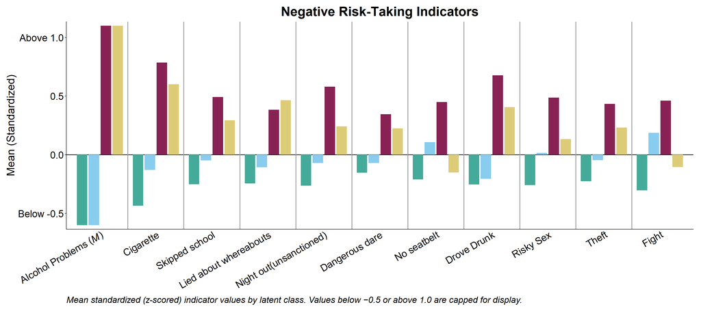

Figure 3

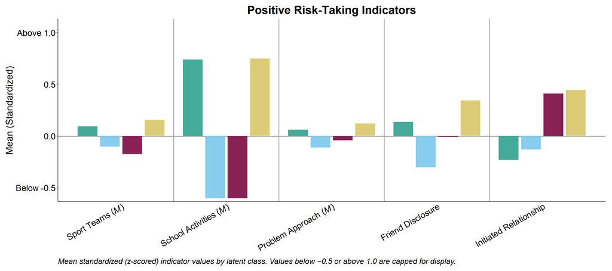

Figure 4

# Predictor Profiles

#### Overview

Predictor profiles show where the four classes fall on the variables being tested as correlates of class membership, biological sex, age, peer substance use, pubertal timing, and autonomy-supportive parenting (ASP).

- Biological sex was a moderately discriminating covariate (4 of 6 pairwise comparisons significant),
- age, pubertal timing, and ASP each discriminated broadly (5 of 6 significant), and
- peer substance use discriminated across all 6 comparisons and was the single most consistent predictor of profile membership.

```r
# Display the raw predictor-profile import before reshaping
gt(head(pred_raw, 6)) |> tab_header(title = "predictor profiles R — predictor means/proportions by class")
```

predictor profiles R — predictor means/proportions by class

| Covariate | label | Cluster1 | Cluster2 | Cluster3 | Cluster4 | Overall |
| --- | --- | --- | --- | --- | --- | --- |
| size | Cluster Size | 0.3558 | 0.3370 | 0.1582 | 0.1489 | NA |
| Zmale | male (percentage) | 0.3747 | 0.6438 | 0.6430 | 0.3692 | NA |
| Zfemale | female (percentage) | 0.6253 | 0.3562 | 0.3570 | 0.6308 | NA |
| Zwave1age | average age | -0.3145 | -0.1210 | 0.4032 | 0.2756 | NA |
| Zpeer_subuse | average peer substance use | -0.4697 | -0.2053 | 1.0049 | 0.6424 | NA |
| Zub_timing | average pubertal timing | -0.0381 | -0.1245 | 0.2014 | 0.2193 | NA |

#### Build Dataframes

Standardized profile dataframe (z-scored predictors + % male).

```r
# Reshape and label the predictor-profile data for class-level plotting
pred_order <- c("Zmale", "Zwave1age", "Zpeer_subuse", "Zub_timing", "Zasp")

display_labels <- c(
  "Zmale"        = "% Male",
  "Zwave1age"    = "Age",
  "Zpeer_subuse" = "Peer SU",
  "Zub_timing"   = "Puberty",
  "Zasp"         = "ASP")

profile_df <- pred_raw %>%
  filter(Covariate %in% pred_order) %>%
  select(-Overall) %>%
  pivot_longer(
    cols = c(Cluster1, Cluster2, Cluster3, Cluster4),
    names_to = "cluster", values_to = "value") %>%
  mutate(
    cluster   = factor(recode(cluster,
                   Cluster1 = "C1", Cluster2 = "C2",
                   Cluster3 = "C3", Cluster4 = "C4"),
                 levels = c("C1","C2","C3","C4")),
    Covariate = factor(Covariate, levels = pred_order),
    display   = factor(display_labels[as.character(Covariate)],
                       levels = display_labels[pred_order]))
```

```r
# Display the cleaned long-format predictor data used in the profile figures
gt(head(profile_df, 8)) |> tab_header(title = "After: long format, one row per predictor x cluster")
```

After: long format, one row per predictor x cluster

| Covariate | label | cluster | value | display |
| --- | --- | --- | --- | --- |
| Zmale | male (percentage) | C1 | 0.3747 | % Male |
| Zmale | male (percentage) | C2 | 0.6438 | % Male |
| Zmale | male (percentage) | C3 | 0.6430 | % Male |
| Zmale | male (percentage) | C4 | 0.3692 | % Male |
| Zwave1age | average age | C1 | -0.3145 | Age |
| Zwave1age | average age | C2 | -0.1210 | Age |
| Zwave1age | average age | C3 | 0.4032 | Age |
| Zwave1age | average age | C4 | 0.2756 | Age |

Unstandardized dataframe (raw means per cluster).

```r
# Build the unstandardized predictor-profile plot for direct interpretation in original units
unstand_order <- c("male", "wave1age", "peer_subuse", "pub_timing", "asp")

unstand_df <- pred_raw %>%
  filter(Covariate %in% unstand_order) %>%
  select(-Overall) %>%
  pivot_longer(
    cols = c(Cluster1, Cluster2, Cluster3, Cluster4),
    names_to = "cluster", values_to = "value" ) %>%
  mutate(
    cluster   = factor(recode(cluster,
                   Cluster1 = "C1", Cluster2 = "C2",
                   Cluster3 = "C3", Cluster4 = "C4"),
                 levels = c("C1","C2","C3","C4")),
    Covariate = factor(Covariate, levels = unstand_order) )
```

Age distribution dataframe. Oldest group (18–19) stacks at the top.

```r
# Prepare age-group distributions across the four latent profiles
age_order <- c("age_13", "age_14", "age_16", "age_17", "age_18")

age_df <- pred_raw %>%
  filter(Covariate %in% age_order) %>%
  select(-Overall) %>%
  pivot_longer(
    cols = c(Cluster1, Cluster2, Cluster3, Cluster4),
    names_to = "cluster", values_to = "proportion" ) %>%
  mutate(
    cluster   = factor(recode(cluster,
                   Cluster1 = "C1", Cluster2 = "C2",
                   Cluster3 = "C3", Cluster4 = "C4"),
                 levels = c("C1","C2","C3","C4")),
    age_group = factor(label, levels = c(
      "18-19 years old", "17 years old", "16 years old",
      "14-15 years old", "13 years old"  )))
```

#### Predictor Profile Graph (Standardized)

```r
# Cluster sizes
cluster_sizes_z <- c("C1" = 35.6, "C2" = 33.7, "C3" = 15.8, "C4" = 14.9)

# Create the description for each cluster
cluster_descriptions <- c(
  "C1" = "High PR - Low NR",
  "C2" = "Low PR - Low NR",
  "C3" = "Low PR - High NR",
  "C4" = "High PR - High NR")

cluster_labels_z <- setNames(
  paste0(names(cluster_sizes_z), ": ", cluster_descriptions),
  names(cluster_sizes_z))

# Colors — pulls from cluster_colors defined in _setup.R
zscore_colors <- cluster_colors

# Create predictor profile plot
p_profile <- ggplot(profile_df, aes(x = display, y = value, fill = cluster)) +
  geom_vline(
    xintercept = seq(1.5, length(profile_df) - 0.5, by = 1),
    color      = "#DDDDDD",
    linewidth  = 0.4) +
  geom_col(position = position_dodge(width = dodge_width), width = bar_width) +
  geom_hline(yintercept = 0, color = ref_line_color,
             linewidth = ref_line_lwd, linetype = ref_line_type) +
 scale_fill_manual(values = cluster_colors, labels = cluster_labels_z) +
  scale_y_continuous(
    name   = "Mean (Standardized)",
    limits = c(-.5, 1.15),
    breaks = seq(-.5, 1, by = .5),
    labels = number_format(accuracy = 0.01)) +
  labs(
    title   = "ASP and Covariate Levels Across Profiles",
    caption = str_wrap("Note. Age, Peer Substance Use, Pubertal Timing, and Autonomy Supportive Parenting were standardized (M = 0, SD = 1). Sex dummy-coded (0 = male, 1 = female); % Male shown as raw proportion.", width = 150)) +
  base_theme +
  theme(legend.position = "top",
        plot.caption = element_text(
                      hjust = 0,
                      lineheight = 1.2,
                      size   = 16)) +
  guides(fill = guide_legend(nrow = 1))
```

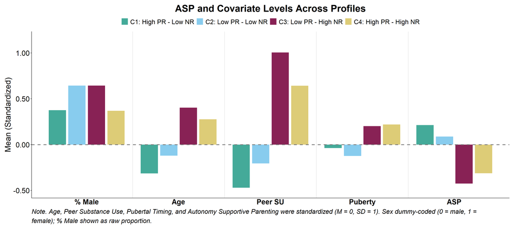

Figure 5

#### Age Distribution

Youngest (13) at bottom; oldest (18–19) at top.

```r
# Create age distribution plot
p_age <- ggplot(age_df, aes(x = cluster, y = proportion, fill = age_group)) +
  geom_col(position = "stack", width = bar_width) +
  scale_fill_manual(
    values = age_colors, name = "Age Group",
    breaks = c("13 years old","14-15 years old","16 years old",
               "17 years old","18-19 years old") ) +
  scale_y_continuous(
    name   = "Proportion",
    limits = c(0, 1.01), expand = c(0, 0),
    breaks = seq(0, 1, by = 0.25),
    labels = number_format(accuracy = 0.01)) +
  labs(
    title   = "Age Distribution by Cluster",
    caption = str_wrap(
      "Note. Stacked bars show proportion within each age group per cluster (sum to 1.0). Ordered youngest (bottom) to oldest (top).",
      width = 150) ) +
    or_theme +
  theme(
    axis.title.x    = element_blank(),
    legend.position = "bottom" ,
    legend.text     = element_text(size = 14),
    legend.title    = element_text(size = 15, face = "bold"),
    legend.key.size = unit(1.1, "lines"),
     plot.caption = element_text(
                      hjust = 0,
                      lineheight = 1.2,
                      size   = 16)) +
  guides(fill = guide_legend(nrow =1))
```

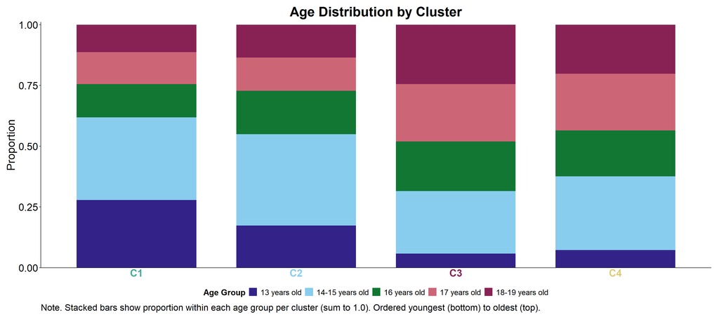

Figure 6

Back to top

## References

Benjamini, Yoav, and Yosef Hochberg. 1995. “Controlling the False Discovery Rate: A Practical and Powerful Approach to Multiple Testing.” *Journal of the Royal Statistical Society Series B: Statistical Methodology* 57 (1): 289–300. https://doi.org/10.1111/j.2517-6161.1995.tb02031.x.

———. 2000. “On the Adaptive Control of the False Discovery Rate in Multiple Testing with Independent Statistics.” *Journal of Educational and Behavioral Statistics* 25 (1): 60–83. https://doi.org/10.2307/1165312.

Dishion, Thomas J, Joan McCord, and Francois Poulin. 1999. “When Interventions Harm: Peer Groups and Problem Behavior.” *American Psychologist*, 10.

Dishion, Thomas J., and Jessica M. Tipsord. 2011. “Peer Contagion in Child and Adolescent Social and Emotional Development.” *Annual Review of Psychology* 62: 189–214. https://doi.org/10.1146/annurev.psych.093008.100412.

Duell, Natasha, and Laurence Steinberg. 2019. “Positive Risk Taking in Adolescence.” *Child Development Perspectives* 13 (1): 48–52. https://doi.org/10.1111/cdep.12310.

———. 2021. “Adolescents Take Positive Risks, Too.” *Developmental Review* 62 (December): 100984. https://doi.org/10.1016/j.dr.2021.100984.

Duell, Natasha, Laurence Steinberg, Grace Icenogle, Jason Chein, Nandita Chaudhary, Laura Di Giunta, Kenneth A. Dodge, et al. 2018. “Age Patterns in Risk Taking Across the World.” *Journal of Youth and Adolescence* 47 (5): 1052–72. https://doi.org/10.1007/s10964-017-0752-y.

Fryt, Joanna, and Monika Szczygiel. 2021. “Predictors of Positive and Negative Risk-Taking in Adolescents and Young Adults: Similarities and Differences.” *Europe’s Journal of Psychology* 17 (1): 17–30. https://doi.org/10.5964/ejop.2169.

Henneberger, Angela K., Dawnsha R. Mushonga, and Alison M. Preston. 2021. “Peer Influence and Adolescent Substance Use: A Systematic Review of Dynamic Social Network Research.” *Adolescent Research Review* 6 (1): 57–73. https://doi.org/10.1007/s40894-019-00130-0.

Miller, Shari, Patrick S. Malone, and Kenneth A. Dodge. 2010. “Developmental Trajectories of Boys’ and Girls’ Delinquency: Sex Differences and Links to Later Adolescent Outcomes.” *Journal of Abnormal Child Psychology* 38 (7): 1021–32. https://doi.org/10.1007/s10802-010-9430-1.

Moffitt, Terrie E. 2017. “Adolescence-Limited and Life-Course-Persistent Antisocial Behavior: A Developmental Taxonomy.” *Biosocial Theories of Crime*, 6996.

Natsuaki, Misaki N., Michael C. Biehl, and Xiaojia Ge. 2009. “Trajectories of Depressed Mood From Early Adolescence to Young Adulthood: The Effects of Pubertal Timing and Adolescent Dating.” *Journal of Research on Adolescence* 19 (1): 47–74. https://doi.org/10.1111/j.1532-7795.2009.00581.x.

Vermunt, J. K., and J. Magidson. 2005. *Technical Guide for Latent Gold Choice 4.0: Basic and Advanced*. Belmont Massachusetts: Statistical Innovations Inc.